# Fundamentos de Análisis de Datos

#### 5.2.1.1 Diagnóstico del modelo

Realizamos el análisis de residuos del modelo final:

```r
# Test de hipótesis para el análisis de normalidad de los residuos
test_normalidad(modelo_final$residuals)
```

```
##
##  Anderson-Darling normality test
##
## data:  df_var
## A = 114.51, p-value < 2.2e-16
##
##
##  Cramer-von Mises normality test
##
## data:  df_var
## W = 19.178, p-value = 7.37e-10
##
##
##  Lilliefors (Kolmogorov-Smirnov) normality test
##
## data:  df_var
## D = 0.075954, p-value < 2.2e-16
```

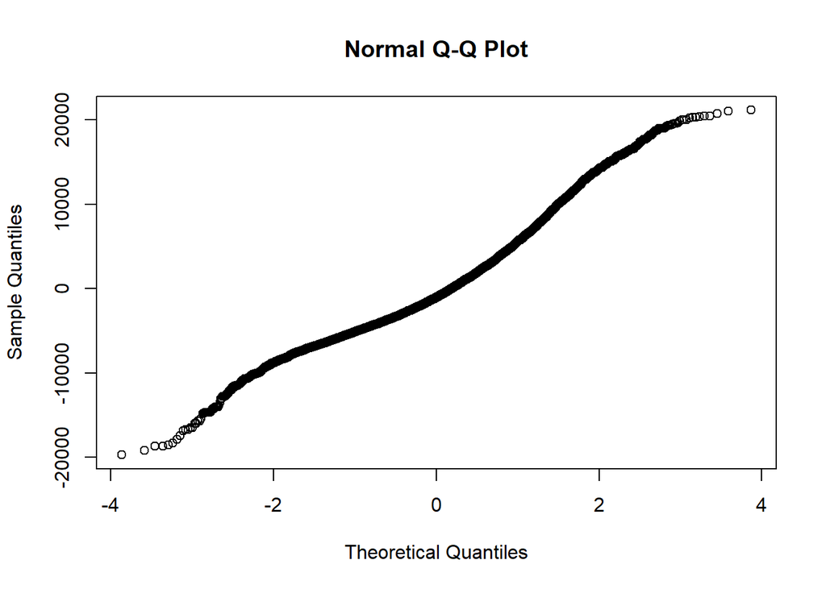

Una visión más amplia de los residuos:

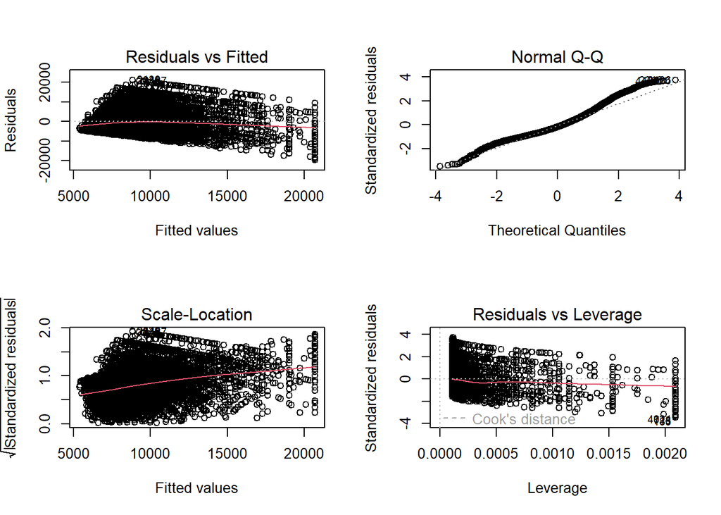

```r
par(mfrow=c(2,2))
plot(modelo_final)
```

En el gráfico de residuos y ajustes observamos que no tienen forma de embudo,lo que evidenciaría la homocedasticidad, pero no se ve en este caso.

Sobre los puntos influyentes se puede ver el grafíco de abajo a la derecha, aquellos a en los extremos serán los que pueden influir, en este caso no se ve algún caso, por ejemplo los casos que eliminamos al principio, si no los hubieramos elimnado saldrían destacados en este gráfico.

Test de contraste de homocedasticidad Breusch-Pagan

Hipótesis nula: los errores tienen varianza constante (homocedasticidad) H1:los errores no tienen varianza constante (heterocedasticidad)

```r
bptest(modelo_final)
```

```
##
##  studentized Breusch-Pagan test
##
## data:  modelo_final
## BP = 799.96, df = 1, p-value < 2.2e-16
```

Como el p-valor es pequeño entonces hay evidencias para rechazar la hipótesis nula de homocedasticida, corroborando lo visto graficamente

¿Hay colinealidad?

Al ser un modelo tan simple, no puede, pero para evaluarlo se calculan los factores de inlación de la varianza (VIF)

Cómo interpretar los valores de VIF: *El valor de VIF comienza en 1 y no tiene límite superior. Una regla general para interpretar los VIF es la siguiente:

*Un valor de 1 indica que no hay correlación entre una variable explicativa dada y cualquier otra variable explicativa en el modelo.* Un valor entre 1 y 5 indica una correlación moderada entre una variable explicativa dada y otras variables explicativas en el modelo, pero esto a menudo no es lo suficientemente grave como para requerir atención. *Un valor mayor que 5 indica una correlación potencialmente severa entre una variable explicativa dada y otras variables explicativas en el modelo. En este caso, las estimaciones de los coeficientes y los valores p en el resultado de la regresión probablemente no sean confiables.

Una vez obtenido el valor de VIF para cada una de las variables independientes de un conjunto de datos es posible identificar las variables más dependientes y eliminarlas. El proceso que se debería seguir para solucionar la multicolinealidad con VIF es:

1.Obtener el VIF para todas las variables independientes 2.Identificar la que tiene el valor máximo de VIF, solamente una, aunque existan dos o más con el mismo valor 3.Si esta variable supera un valor umbral, por ejemplo 5, eliminarla y volver al punto 1. En caso contrario se termina el proceso.

Es importante eliminar únicamente una variable en cada paso, ya que en caso contrario se podría eliminar todas las variables relacionadas. Por ejemplo, si tenemos una variable que es dos veces otra, en tal caso ambas tendrán un valor de VIF que tiende a infinito, ya que el R^2 es igual a uno. Si eliminamos ambas se eliminan todas las ocurrencias de esa variable, que no es lo que se desea.

```r
# Factores de inflación de la varianza......DARIA ERROR AL SOLO TENER UN TERMINO, UNA VARIALE INDEPENDIENTE
#car::vif(modelo_final)
```

Incorrelación de los residuos: Comprobar la incorrelación para los residuos estudentizados del modelo ajustado. Se realiza a través del Test de Durbin-Watson (asume bajo la hipótesis nula que no existe correlación). La función dwtest( ) realiza este contraste directamente sobre los residuos estudentizados.

```r
dwtest( modelo_final,
        alternative = "two.sided",
        data = train)
```

```
##
##  Durbin-Watson test
##
## data:  modelo_final
## DW = 1.9887, p-value = 0.5892
## alternative hypothesis: true autocorrelation is not 0
```

### 5.2.2 EStimación de predicciones

Previamente tratamos el fichero de validación, realizaremos las mismas modificacines al fichero de test que hicimos al de train para poder ejecutar el modelo en las mismas condiciones.

```r
validacion$person_home_ownership[validacion$person_home_ownership=="OTHER"] <-"RENT"


validacion$cb_person_cred_hist_length_cat <- cut(validacion$cb_person_cred_hist_length,c(0,4,10,Inf),
                                            labels = c("0-4", "5-10", "Más de 10") )

validacion$person_emp_length[is.na(validacion$person_emp_length)] <-median(train$person_emp_length, na.rm=T)
validacion$loan_int_rate[is.na(validacion$loan_int_rate)] <-median(train$loan_int_rate, na.rm=T)
```

Comprobación rápida que ya no tenemos missing

```r
apply(is.na(validacion),2,FUN="mean")*100
```

```
##                     person_age                  person_income
##                              0                              0
##          person_home_ownership              person_emp_length
##                              0                              0
##                    loan_intent                     loan_grade
##                              0                              0
##                         target                  loan_int_rate
##                              0                              0
##                    loan_status            loan_percent_income
##                              0                              0
##      cb_person_default_on_file     cb_person_cred_hist_length
##                              0                              0
## cb_person_cred_hist_length_cat
##                              0
```

Transformaciones de variables para que sigan la hipótesis de normalidad de los datos.

```r
(orderNorm_obj_age_val <- orderNorm(validacion$person_age))
```

```
## orderNorm Transformation with 3910 nonmissing obs and ties
##  - 46 unique values
##  - Original quantiles:
##   0%  25%  50%  75% 100%
##   20   23   26   30  123
```

```r
validacion$person_age_tr <- orderNorm_obj_age_val$x

(orderNorm_obj_in_val <- orderNorm(validacion$person_income))
```

```
## orderNorm Transformation with 3910 nonmissing obs and ties
##  - 971 unique values
##  - Original quantiles:
##     0%    25%    50%    75%   100%
##   8000  38400  55000  80000 780000
```

```r
validacion$person_income_tr <- orderNorm_obj_in_val$x

(sqrt_x_object_len_val <- sqrt_x(validacion$person_emp_length))
```

```
## Standardized sqrt(x + a) Transformation with 3910 nonmissing obs.:
##  Relevant statistics:
##  - a = 0
##  - mean (before standardization) = 1.920151
##  - sd (before standardization) = 1.036418
```

```r
validacion$person_emp_length_tr <- sqrt_x_object_len_val$x
```

Comparamos que los datos de train y de validacion siguen las misma distribución por variable, esta fase es muy importante porque cualquier cambio de distribución en alguna variable que luego entra en el modelo puede provocar que no ajuste bien el modelo, en este caso al ser una muestra aleatoria del mismo dataframe es muy complicado que pase, pero si el fichero de validación es de otro periodo estacional, podría, por lo que esta fase es siempre esencial.

Aunque a priori sólo se podría ver en aquellas variables que entran en el modelo, es recomendable ver también las más relvantes de tus datos por conocimientos de la materia por si ya se aprecian otros cambios y se pueden encontrar explicaciones de los mismos.

Lo ideal es poner gráficos superpuestos….para ver mejor los cambios e incluir información de valores, missing, media, mediana, percentiles, porcentajes de 0….te puede pasar que en los nuevos datos, validación, tengas un missing y en los de entrenamiento, no,… (lo normal es que te dé error al ejecutar el modelo, pero si en la variable de entrenamiento no tiene ceros y luego en el de validación sí, que están enmascarados los valores missing, el modelo no te daría error, pero los resultados serán una sorpresa)

[figure not shown]

```r
grafico_train_val_num(train,validacion,cb_person_cred_hist_length)
```

**Ingresos personales (person_income)**

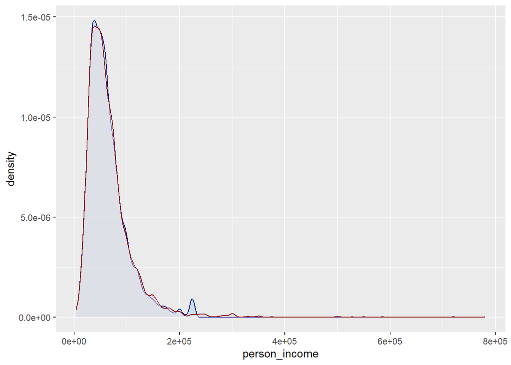

```r
grafico_train_val_num(train,validacion,person_income)
```

**Tiempo trabajado (person_emp_length)**

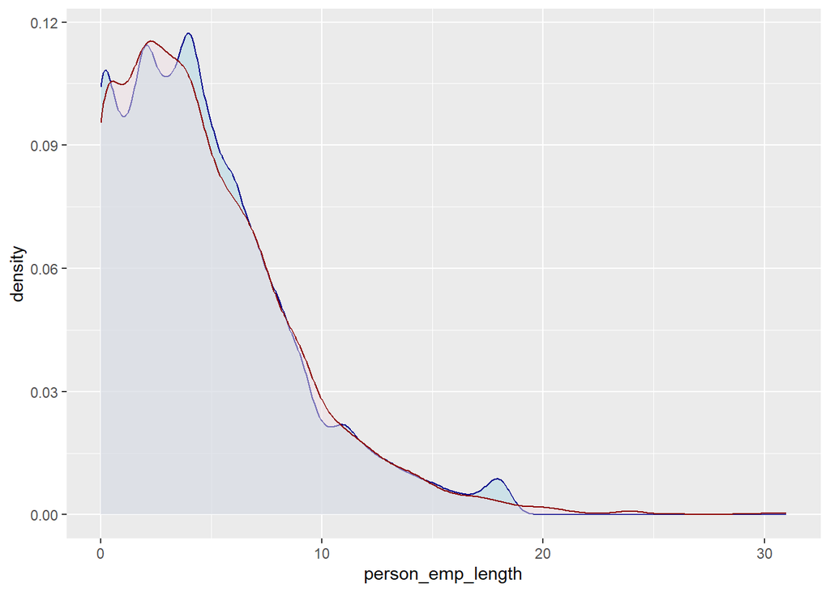

```r
grafico_train_val_num(train,validacion,person_emp_length)
```

**Tasa de interés (loan_int_rate)**

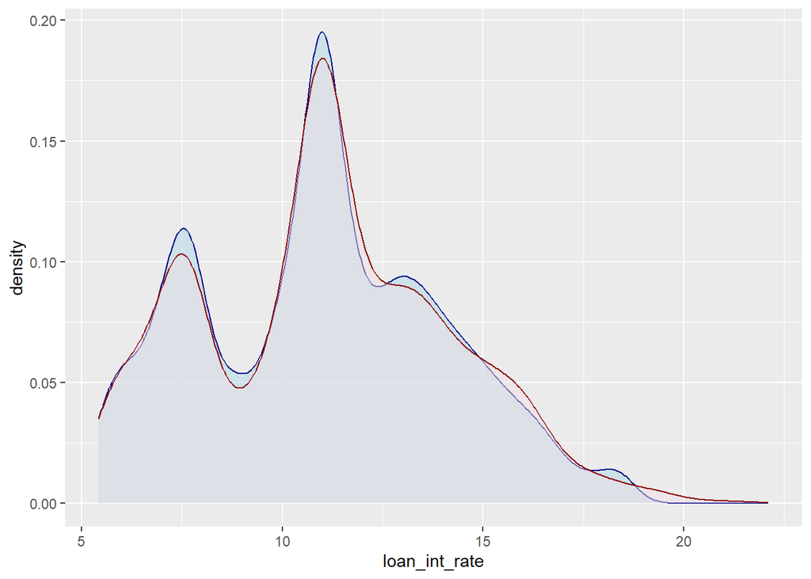

```r
grafico_train_val_num(train,validacion,loan_int_rate)
```

**Lapso de tiempo desde el anterior préstamo (cb_person_cred_hist_length)**

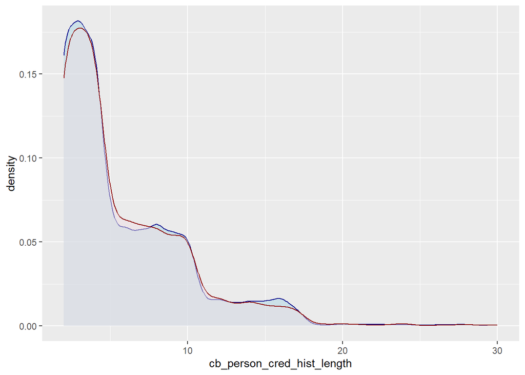

```r
grafico_train_val_num(train,validacion,cb_person_cred_hist_length)
```

**Relación con la propiedad de la vivienda (person_home_ownership)**

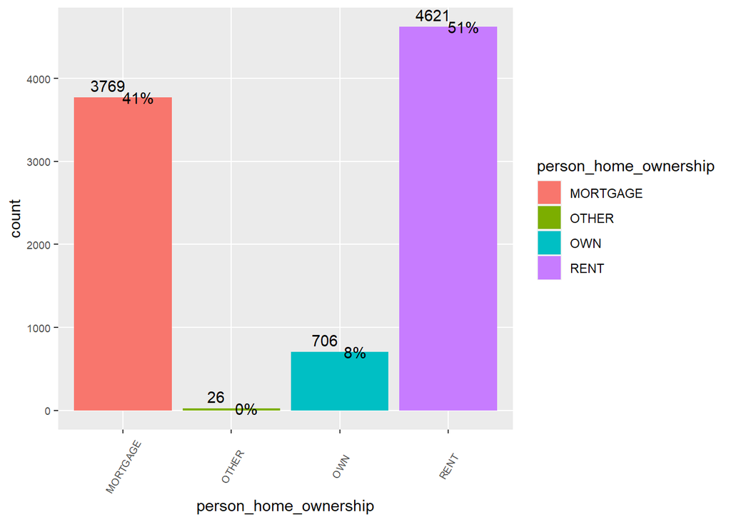

```r
a2_val=grafico_categoricas33(validacion,person_home_ownership)
a2
```

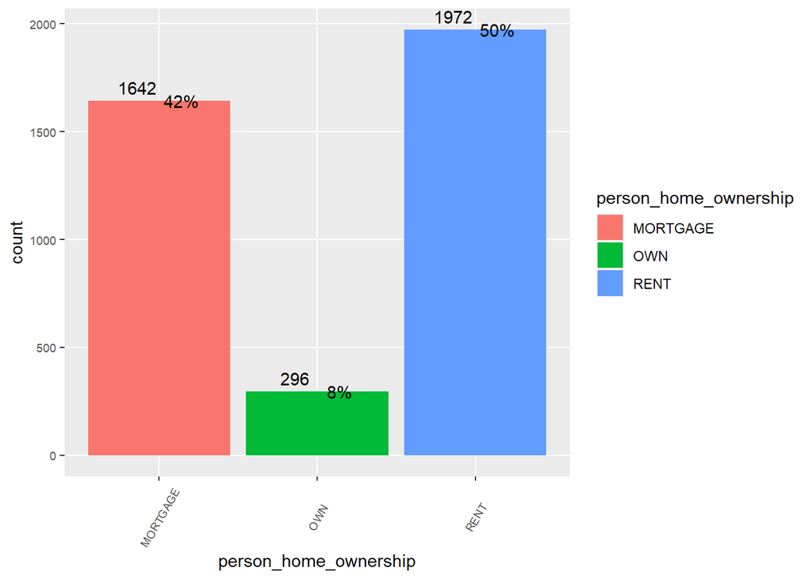

```r
a2_val
```

El valor infrecuente de OTHER se le asignará el valor más frecuente RENT.

**Motivo del préstamo (loan_intent)**

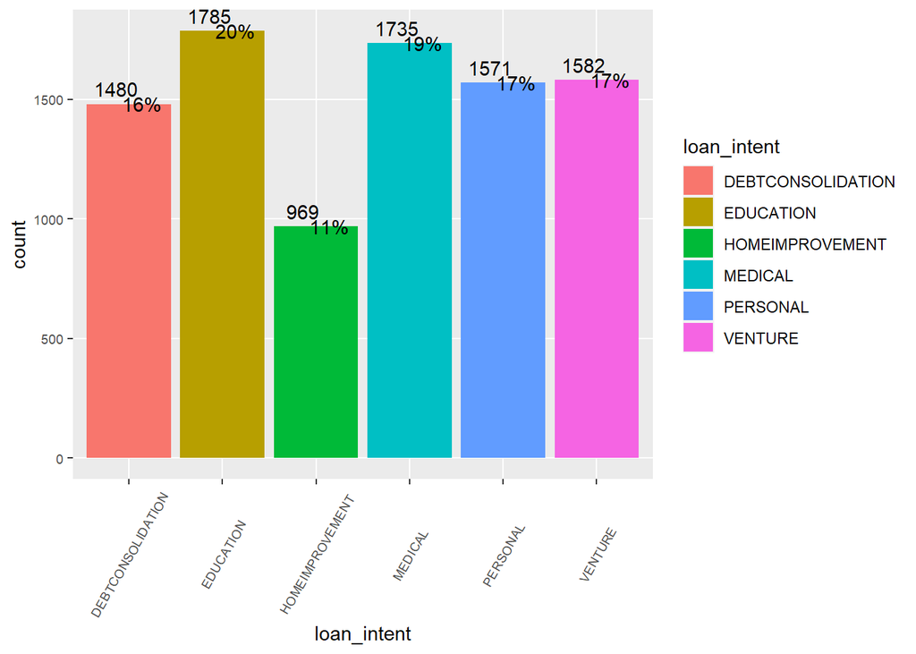

```r
a3_val=grafico_categoricas33(validacion,loan_intent)
a3
```

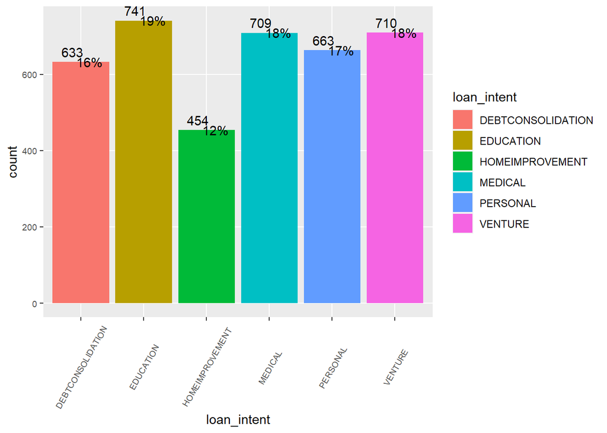

```r
a3_val
```

**Falta de pago de un préstamo antiguo (cb_person_default_on_file)**

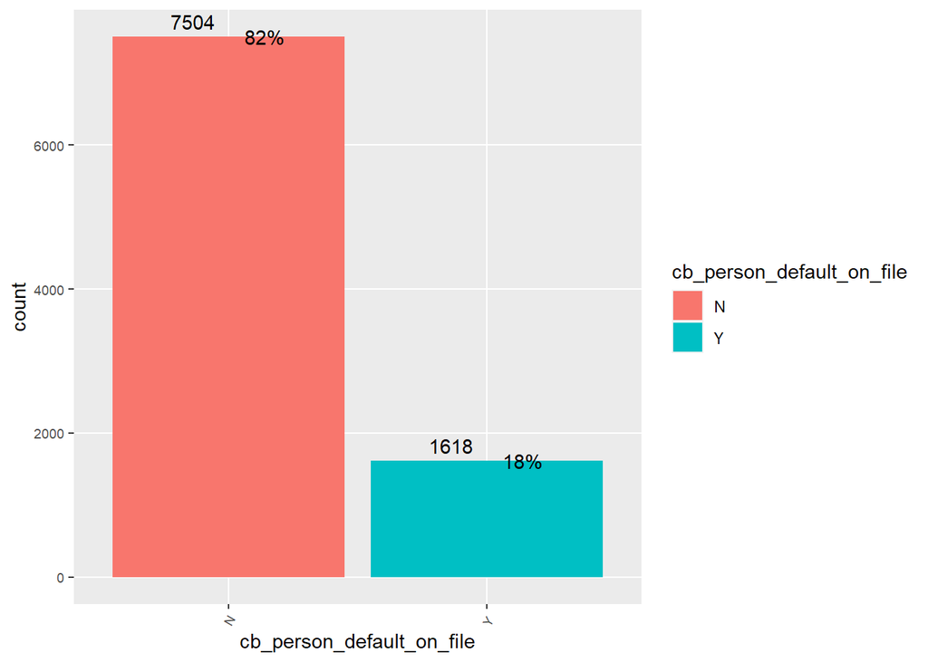

```r
a4_val=grafico_categoricas33(validacion,cb_person_default_on_file)
a4
```

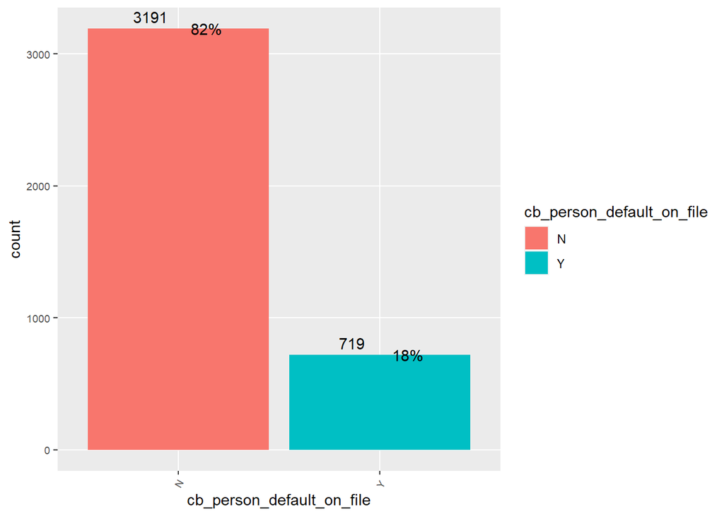

```r
a4_val
```

Y ahora generamos un fichero con las predicciones con el modelo fijado:

```r
predicciones <- predict(object=modelo_final, newdata=validacion)
```

Sobre estas prediciones también habría que evaluar las diferencias entre valor real y estimado similar al train y en el caso de que se tengan varios candidatos se podrían comparar los resultados sobre este fichero de validación.

Y con esto finalizaríamos el trabajo, hemos ido un poco justos de tiempo por lo que se verá que el detalle y el mimo de los gráficos, las salidas y comentarios no es el desado.

# 6 Versiones y paquetes instalados de R

```r
 sesion_info <- devtools::session_info()
dplyr::select(
  tibble::as_tibble(sesion_info$packages),
  c(package, loadedversion, source)
)
```

```
## # A tibble: 144 × 3
##    package       loadedversion source
##    <chr>         <chr>         <chr>
##  1 abind         1.4-5         CRAN (R 4.2.0)
##  2 assertthat    0.2.1         CRAN (R 4.2.1)
##  3 backports     1.4.1         CRAN (R 4.2.0)
##  4 bestNormalize 1.8.3         CRAN (R 4.2.2)
##  5 boot          1.3-28        CRAN (R 4.2.1)
##  6 broom         1.0.1         CRAN (R 4.2.1)
##  7 bslib         0.4.0         CRAN (R 4.2.1)
##  8 butcher       0.3.1         CRAN (R 4.2.2)
##  9 cachem        1.0.6         CRAN (R 4.2.1)
## 10 callr         3.7.2         CRAN (R 4.2.1)
## # … with 134 more rows
```

Versión de R:

```r
version
```

```
##                _
## platform       x86_64-w64-mingw32
## arch           x86_64
## os             mingw32
## crt            ucrt
## system         x86_64, mingw32
## status
## major          4
## minor          2.1
## year           2022
## month          06
## day            23
## svn rev        82513
## language       R
## version.string R version 4.2.1 (2022-06-23 ucrt)
## nickname       Funny-Looking Kid
```